# Homework 04

## Cross-sell / Up-sell using Recommendations

## Due date : 26 April 23:59

## BDA - University of Tartu - Spring 2020

# Homework instructions

- Insert your team member names and student IDs in the field "Team mates" below. If you are not working in a team please insert only your name, surname and student ID
- The accepted submission formats are Colab links or .ipynb files. If you are submitting Colab links please make sure that the privacy settings for the file is public so we can access your code.
- The submission will automatically close at 12:00 am, so please make sure you have enough time to submit the homework.
- Only one of the teammates should submit the homework. We will grade and give points to both of you!
- You do not necessarily need to work on Colab. Especially as the size and the complexity of datasets will increase through the course, you can install jupyter notebooks locally and work from there.
- If you do not understand what a question is asking for, please ask in Moodle.

## Team mates:

Name Surname: Enlik - Student ID: B96323

Name Surname: Thi Thuy Nga Vu Student ID: B88416

# 1. Market Basket Analysis (2 points)

**1.1 Consider the following businesses and think about one case of cross selling and one case of up selling techniques they could use. This question is not restricted to only traditional, standard examples. If you wish you can provide something that you would like these businesses to do. (1 points)**

a. An OnlineTravel Agency like Booking.com or AirBnB

**Cross selling:** recommend some tour packages made by locals

**Up selling:** get the booking cancellation for free by adding extra 10% of the booking price

b. A software company which produces products related to cyber security like Norton, Kaspersky, Avast and similar ones.

**Cross selling:** get 50% discount for the mobile version (Android/iOS) when purchase our subscription plan in Windows/Mac

**Up selling:** get the best value (30% cheaper compare to monthly plan) when subscribe our yearly plan

c. A company that sells cell phones

**Cross selling:** give an offer to purchase high-quality screen protector and phone case that suits to the phone that you will buy.

**Up selling:** get additional 128GB internal storage just by adding 50EUR to current price

d. A supermarket like Konsum, Rimi, Maxima etc.

**Cross selling:** group the similar products together for a specific occasion, for example **Christmas** season, when customer can buy decoration, gift wrap, chocolate, and other christmas gifts in one place

**Up selling:** give an incentive (for example: extra 50% loyalty reward point) when customer spending more than 50EUR in one-time shopping

```python
import pandas as pd

df = pd.read_csv('OnlineRetailPurchase.csv', header=0 )
```

```python
df.head()
```

|  | InvoiceNo | StockCode | Description | Quantity | InvoiceDate | UnitPrice | CustomerID | Country |
| --- | --- | --- | --- | --- | --- | --- | --- | --- |
| 0 | 536365 | 85123A | WHITE HANGING HEART T-LIGHT HOLDER | 6 | 12/1/2010 8:26 | 2.55 | 17850.0 | United Kingdom |
| 1 | 536365 | 71053 | WHITE METAL LANTERN | 6 | 12/1/2010 8:26 | 3.39 | 17850.0 | United Kingdom |
| 2 | 536365 | 84406B | CREAM CUPID HEARTS COAT HANGER | 8 | 12/1/2010 8:26 | 2.75 | 17850.0 | United Kingdom |
| 3 | 536365 | 84029G | KNITTED UNION FLAG HOT WATER BOTTLE | 6 | 12/1/2010 8:26 | 3.39 | 17850.0 | United Kingdom |
| 4 | 536365 | 84029E | RED WOOLLY HOTTIE WHITE HEART. | 6 | 12/1/2010 8:26 | 3.39 | 17850.0 | United Kingdom |

**1.2 Use describe function from pandas to get statistical information about the values in the dataframe. Do you notice something which might not be correct? If so please perform the necessary operations. (Hint: Remember what we did in the practice session 03)(0.25 points)**

```python
df.describe()
```

|  | Quantity | UnitPrice | CustomerID |
| --- | --- | --- | --- |
| count | 10000.000000 | 10000.000000 | 7709.000000 |
| mean | 7.828600 | 3.837412 | 15615.462576 |
| std | 104.322417 | 14.310148 | 1756.540802 |
| min | -9360.000000 | 0.000000 | 12395.000000 |
| 25% | 1.000000 | 1.250000 | 14388.000000 |
| 50% | 2.000000 | 2.510000 | 15605.000000 |
| 75% | 8.000000 | 4.210000 | 17228.000000 |
| max | 2880.000000 | 887.520000 | 18239.000000 |

```python
print(sum(df['Quantity'] < 0))
```

```
130
```

```python
# Remove all rows with quantity less than zero
df = df[df['Quantity'] >= 0]
df.describe()
```

|  | Quantity | UnitPrice | CustomerID |
| --- | --- | --- | --- |
| count | 9870.000000 | 9870.000000 | 7609.000000 |
| mean | 9.169301 | 3.837023 | 15620.763832 |
| std | 45.747927 | 14.391451 | 1755.451331 |
| min | 1.000000 | 0.000000 | 12395.000000 |
| 25% | 1.000000 | 1.250000 | 14388.000000 |
| 50% | 3.000000 | 2.510000 | 15640.000000 |
| 75% | 8.000000 | 4.210000 | 17228.000000 |
| max | 2880.000000 | 887.520000 | 18239.000000 |

```python
df['Description'] = df['Description'].str.strip()
df.dropna(axis=0, subset=['InvoiceNo'], inplace=True)
df['InvoiceNo'] = df['InvoiceNo'].astype('str')
df = df[~df['InvoiceNo'].str.contains('C')]
df.head()
```

|  | InvoiceNo | StockCode | Description | Quantity | InvoiceDate | UnitPrice | CustomerID | Country |
| --- | --- | --- | --- | --- | --- | --- | --- | --- |
| 0 | 536365 | 85123A | WHITE HANGING HEART T-LIGHT HOLDER | 6 | 12/1/2010 8:26 | 2.55 | 17850.0 | United Kingdom |
| 1 | 536365 | 71053 | WHITE METAL LANTERN | 6 | 12/1/2010 8:26 | 3.39 | 17850.0 | United Kingdom |
| 2 | 536365 | 84406B | CREAM CUPID HEARTS COAT HANGER | 8 | 12/1/2010 8:26 | 2.75 | 17850.0 | United Kingdom |
| 3 | 536365 | 84029G | KNITTED UNION FLAG HOT WATER BOTTLE | 6 | 12/1/2010 8:26 | 3.39 | 17850.0 | United Kingdom |
| 4 | 536365 | 84029E | RED WOOLLY HOTTIE WHITE HEART. | 6 | 12/1/2010 8:26 | 3.39 | 17850.0 | United Kingdom |

**1.3 Create a dataframe name as "Basket", where each row has an distintive value of InvoiceNo and each column has a distinctive Description. The cells in the table contain the count of each item (Description) mentioned in one invoice. For example basket.loc['536365','WHITE HANGING HEART T-LIGHT HOLDER'] has a value of 1 because the product with WHITE HANGING HEART T-LIGHT HOLDER was entered only once in the invoice 536365. Hint: Remember the function you used in Homework 1 for a similar task or in practice session no.07 (0.25 points)**

```python
# Reference from Lab 07 - Reommendations System
## get number of ratings given by every user
# df_users_cnt = pd.DataFrame(df_ratings_drop_movies.groupby('userId').size(), columns=['count'])
# df_users_cnt.head()

# basket = pd.DataFrame(df.groupby(['InvoiceNo', 'Description']).sum().unstack().reset_index().set_index('InvoiceNo'))
# basket.rename_axis(None, inplace=True)

# basket = pd.DataFrame(df.groupby(['InvoiceNo', 'Description']).size(), columns=['Count'])

# Reference:
# https://pbpython.com/market-basket-analysis.html
# basket = (df.groupby(['InvoiceNo', 'Description'])['Quantity']
#           .sum().unstack().reset_index().fillna(0)
#           .set_index('InvoiceNo'))
basket = (df.groupby(['InvoiceNo', 'Description'])
              .size().unstack().reset_index().fillna(0).set_index('InvoiceNo'))
basket.head()
```

| Description InvoiceNo | 10 COLOUR SPACEBOY PEN | 12 COLOURED PARTY BALLOONS | 12 DAISY PEGS IN WOOD BOX | 12 IVORY ROSE PEG PLACE SETTINGS | 12 MESSAGE CARDS WITH ENVELOPES | 12 PENCIL SMALL TUBE WOODLAND | 12 PENCILS SMALL TUBE RED RETROSPOT | 12 PENCILS SMALL TUBE SKULL | 12 PENCILS TALL TUBE POSY | 12 PENCILS TALL TUBE RED RETROSPOT | ... | YELLOW/PINK FLOWER DESIGN BIG MUG | YOU'RE CONFUSING ME METAL SIGN | YULETIDE IMAGES GIFT WRAP SET | YULETIDE IMAGES S/6 PAPER BOXES | ZINC FINISH 15CM PLANTER POTS | ZINC FOLKART SLEIGH BELLS | ZINC HEART LATTICE T-LIGHT HOLDER | ZINC METAL HEART DECORATION | ZINC WILLIE WINKIE CANDLE STICK | amazon |
| --- | --- | --- | --- | --- | --- | --- | --- | --- | --- | --- | --- | --- | --- | --- | --- | --- | --- | --- | --- | --- | --- |
| 536365 | 0.0 | 0.0 | 0.0 | 0.0 | 0.0 | 0.0 | 0.0 | 0.0 | 0.0 | 0.0 | ... | 0.0 | 0.0 | 0.0 | 0.0 | 0.0 | 0.0 | 0.0 | 0.0 | 0.0 | 0.0 |
| 536366 | 0.0 | 0.0 | 0.0 | 0.0 | 0.0 | 0.0 | 0.0 | 0.0 | 0.0 | 0.0 | ... | 0.0 | 0.0 | 0.0 | 0.0 | 0.0 | 0.0 | 0.0 | 0.0 | 0.0 | 0.0 |
| 536367 | 0.0 | 0.0 | 0.0 | 0.0 | 0.0 | 0.0 | 0.0 | 0.0 | 0.0 | 0.0 | ... | 0.0 | 0.0 | 0.0 | 0.0 | 0.0 | 0.0 | 0.0 | 0.0 | 0.0 | 0.0 |
| 536368 | 0.0 | 0.0 | 0.0 | 0.0 | 0.0 | 0.0 | 0.0 | 0.0 | 0.0 | 0.0 | ... | 0.0 | 0.0 | 0.0 | 0.0 | 0.0 | 0.0 | 0.0 | 0.0 | 0.0 | 0.0 |
| 536369 | 0.0 | 0.0 | 0.0 | 0.0 | 0.0 | 0.0 | 0.0 | 0.0 | 0.0 | 0.0 | ... | 0.0 | 0.0 | 0.0 | 0.0 | 0.0 | 0.0 | 0.0 | 0.0 | 0.0 | 0.0 |

5 rows × 1968 columns

```python
basket.loc['536365','WHITE HANGING HEART T-LIGHT HOLDER']
```

```
1.0
```

```python
basket.loc['537224','WHITE BELL HONEYCOMB PAPER']
```

```
2.0
```

```python
basket.loc['536412','12 DAISY PEGS IN WOOD BOX']
```

```
5.0
```

```python
# basket.describe()
```

**1.4 Some products are mentioned more than once in one invoice. You can check the maximum number for each column to verify. Modify your dataframe such that every cell which has a value higher than one will be replaced with 1. If the cell has the value 0 it will remain the same. (0.25 points)**

```python
# fucntion for "one-hot encoding" of the data
def encode_units(x):
    if x <= 0:
        return 0
    if x >= 1:
        return 1

basket_sets = basket.applymap(encode_units)
#remove "POSTAGE" column because it's not relevant in our association exploration
basket_sets.drop('POSTAGE', inplace=True, axis=1)
```

```python
basket_sets
```

| Description InvoiceNo | 10 COLOUR SPACEBOY PEN | 12 COLOURED PARTY BALLOONS | 12 DAISY PEGS IN WOOD BOX | 12 IVORY ROSE PEG PLACE SETTINGS | 12 MESSAGE CARDS WITH ENVELOPES | 12 PENCIL SMALL TUBE WOODLAND | 12 PENCILS SMALL TUBE RED RETROSPOT | 12 PENCILS SMALL TUBE SKULL | 12 PENCILS TALL TUBE POSY | 12 PENCILS TALL TUBE RED RETROSPOT | ... | YELLOW/PINK FLOWER DESIGN BIG MUG | YOU'RE CONFUSING ME METAL SIGN | YULETIDE IMAGES GIFT WRAP SET | YULETIDE IMAGES S/6 PAPER BOXES | ZINC FINISH 15CM PLANTER POTS | ZINC FOLKART SLEIGH BELLS | ZINC HEART LATTICE T-LIGHT HOLDER | ZINC METAL HEART DECORATION | ZINC WILLIE WINKIE CANDLE STICK | amazon |
| --- | --- | --- | --- | --- | --- | --- | --- | --- | --- | --- | --- | --- | --- | --- | --- | --- | --- | --- | --- | --- | --- |
| 536365 | 0 | 0 | 0 | 0 | 0 | 0 | 0 | 0 | 0 | 0 | ... | 0 | 0 | 0 | 0 | 0 | 0 | 0 | 0 | 0 | 0 |
| 536366 | 0 | 0 | 0 | 0 | 0 | 0 | 0 | 0 | 0 | 0 | ... | 0 | 0 | 0 | 0 | 0 | 0 | 0 | 0 | 0 | 0 |
| 536367 | 0 | 0 | 0 | 0 | 0 | 0 | 0 | 0 | 0 | 0 | ... | 0 | 0 | 0 | 0 | 0 | 0 | 0 | 0 | 0 | 0 |
| 536368 | 0 | 0 | 0 | 0 | 0 | 0 | 0 | 0 | 0 | 0 | ... | 0 | 0 | 0 | 0 | 0 | 0 | 0 | 0 | 0 | 0 |
| 536369 | 0 | 0 | 0 | 0 | 0 | 0 | 0 | 0 | 0 | 0 | ... | 0 | 0 | 0 | 0 | 0 | 0 | 0 | 0 | 0 | 0 |
| ... | ... | ... | ... | ... | ... | ... | ... | ... | ... | ... | ... | ... | ... | ... | ... | ... | ... | ... | ... | ... | ... |
| 537220 | 0 | 0 | 0 | 0 | 0 | 0 | 0 | 0 | 0 | 0 | ... | 0 | 0 | 0 | 0 | 0 | 0 | 0 | 0 | 0 | 0 |
| 537221 | 0 | 0 | 0 | 0 | 0 | 0 | 0 | 0 | 0 | 0 | ... | 0 | 0 | 0 | 0 | 0 | 0 | 0 | 0 | 0 | 0 |
| 537222 | 0 | 0 | 0 | 0 | 0 | 0 | 0 | 0 | 0 | 0 | ... | 0 | 0 | 0 | 0 | 0 | 0 | 0 | 0 | 0 | 0 |
| 537223 | 0 | 0 | 0 | 0 | 0 | 0 | 0 | 0 | 0 | 0 | ... | 0 | 0 | 0 | 0 | 0 | 0 | 0 | 0 | 0 | 0 |
| 537224 | 0 | 0 | 0 | 0 | 0 | 0 | 0 | 0 | 0 | 0 | ... | 0 | 0 | 0 | 0 | 0 | 0 | 0 | 0 | 0 | 0 |

426 rows × 1967 columns

**1.5 We do not need to spend time on calculating the association rules by ourselves as there already exists a package for python to do so, called mlxtend. We are going to use the mlxtend package to find frequent items bought together and then create some rules on what to recomend to a user based on what he/she/they have bought. We have given you the first part of the code which calculates the frequent items bought together.**

```python
#!pip install mlxtend
from mlxtend.frequent_patterns import apriori
from mlxtend.frequent_patterns import association_rules
import mlxtend as ml
import math
```

```python
# Mlxtend has implemented Apriori, a popular algorithm for extracting frequent itemsets
# We can change the value of minimum support but it will
# But as well we get less useful results for the next step.
# Setting use_colnames=True to convert the returned integer indices into item names

frequent_itemsets = apriori(basket_sets, min_support=0.03, use_colnames=True)
frequent_itemsets
```

|  | support | itemsets |
| --- | --- | --- |
| 0 | 0.030516 | (10 COLOUR SPACEBOY PEN) |
| 1 | 0.037559 | (12 PENCILS SMALL TUBE RED RETROSPOT) |
| 2 | 0.032864 | (12 PENCILS SMALL TUBE SKULL) |
| 3 | 0.030516 | (3 PIECE SPACEBOY COOKIE CUTTER SET) |
| 4 | 0.049296 | (6 RIBBONS RUSTIC CHARM) |
| ... | ... | ... |
| 13601 | 0.030516 | (KNITTED UNION FLAG HOT WATER BOTTLE, WOODEN F... |
| 13602 | 0.030516 | (WOODEN FRAME ANTIQUE WHITE, WHITE HANGING HEA... |
| 13603 | 0.030516 | (KNITTED UNION FLAG HOT WATER BOTTLE, WOODEN F... |
| 13604 | 0.030516 | (KNITTED UNION FLAG HOT WATER BOTTLE, WOODEN F... |
| 13605 | 0.030516 | (KNITTED UNION FLAG HOT WATER BOTTLE, WOODEN F... |

13606 rows × 2 columns

```python
rules = association_rules(frequent_itemsets, metric="lift")
rules.head()
```

|  | antecedents | consequents | antecedent support | consequent support | support | confidence | lift | leverage | conviction |
| --- | --- | --- | --- | --- | --- | --- | --- | --- | --- |
| 0 | (60 CAKE CASES VINTAGE CHRISTMAS) | (PAPER CHAIN KIT 50'S CHRISTMAS) | 0.056338 | 0.110329 | 0.032864 | 0.583333 | 5.287234 | 0.026648 | 2.135211 |
| 1 | (PAPER CHAIN KIT 50'S CHRISTMAS) | (60 CAKE CASES VINTAGE CHRISTMAS) | 0.110329 | 0.056338 | 0.032864 | 0.297872 | 5.287234 | 0.026648 | 1.344003 |
| 2 | (PAPER CHAIN KIT VINTAGE CHRISTMAS) | (60 CAKE CASES VINTAGE CHRISTMAS) | 0.100939 | 0.056338 | 0.035211 | 0.348837 | 6.191860 | 0.029525 | 1.449195 |
| 3 | (60 CAKE CASES VINTAGE CHRISTMAS) | (PAPER CHAIN KIT VINTAGE CHRISTMAS) | 0.056338 | 0.100939 | 0.035211 | 0.625000 | 6.191860 | 0.029525 | 2.397496 |
| 4 | (ALARM CLOCK BAKELIKE RED) | (ALARM CLOCK BAKELIKE GREEN) | 0.049296 | 0.058685 | 0.042254 | 0.857143 | 14.605714 | 0.039361 | 6.589202 |

# 2. Collaborative filtering (3.5 points )

We are going to use Books.csv dataset which contains ratings from Amazon website and the data has the following features:

UserID: The ID of the users who read the books

BookTitle: The title of the book

Book-Rating: A rating given to the book in a scale from 0 to 10

Below we are going to perform the same steps we did with movies dataset in the practice session

**2.0 Load the dataset and take a look at the books titles. Please pick one of them which you like (or think that you would like) the most.(0.1 points)**

```python
books = pd.read_csv("Books.csv", header=0)
books.head()
```

|  | UserID | Book-Rating | BookTitle |
| --- | --- | --- | --- |
| 0 | 6181 | 0 | Flesh Tones: A Novel |
| 1 | 62 | 5 | Flesh Tones: A Novel |
| 2 | 163 | 0 | Flesh Tones: A Novel |
| 3 | 212 | 5 | Flesh Tones: A Novel |
| 4 | 250 | 9 | Flesh Tones: A Novel |

```python
# pick my favorite book = 'Harry Potter and the Order of the Phoenix (Book 5)'
books[books['BookTitle'] == 'Harry Potter and the Order of the Phoenix (Book 5)'].head()
```

|  | UserID | Book-Rating | BookTitle |
| --- | --- | --- | --- |
| 1818 | 6198 | 7 | Harry Potter and the Order of the Phoenix (Boo... |
| 1819 | 6283 | 10 | Harry Potter and the Order of the Phoenix (Boo... |
| 1820 | 7 | 0 | Harry Potter and the Order of the Phoenix (Boo... |
| 1821 | 56 | 9 | Harry Potter and the Order of the Phoenix (Boo... |
| 1822 | 117 | 0 | Harry Potter and the Order of the Phoenix (Boo... |

```python
books.iloc[[1818]]
```

|  | UserID | Book-Rating | BookTitle |
| --- | --- | --- | --- |
| 1818 | 6198 | 7 | Harry Potter and the Order of the Phoenix (Boo... |

**2.1 Our next step will be to perform user based collaborative filtering using KNN algorithm. As KNN algorithm does not accept strings, use a Label Encoder for BookTitle column.After that reshape the books matrix using pivot so every column will be a UserID and every row a BookTitle. (0.45 points)**

```python
# Reference
# https://stackoverflow.com/questions/24458645/label-encoding-across-multiple-columns-in-scikit-learn
from sklearn.preprocessing import LabelEncoder
books_encoded = books.apply(LabelEncoder().fit_transform)
books_encoded = books_encoded.rename(columns={"BookTitle": "BookID_Encoded"})
books_encoded
```

|  | UserID | Book-Rating | BookID_Encoded |
| --- | --- | --- | --- |
| 0 | 6181 | 0 | 124 |
| 1 | 62 | 5 | 124 |
| 2 | 163 | 0 | 124 |
| 3 | 212 | 5 | 124 |
| 4 | 250 | 9 | 124 |
| ... | ... | ... | ... |
| 9995 | 3663 | 0 | 333 |
| 9996 | 3665 | 0 | 333 |
| 9997 | 3666 | 3 | 333 |
| 9998 | 3668 | 9 | 333 |
| 9999 | 3670 | 0 | 333 |

10000 rows × 3 columns

```python
books_encoded_no_dup = books_encoded.drop_duplicates(['UserID', 'BookID_Encoded'])
books_encoded_no_dup
```

|  | UserID | Book-Rating | BookID_Encoded |
| --- | --- | --- | --- |
| 0 | 6181 | 0 | 124 |
| 1 | 62 | 5 | 124 |
| 2 | 163 | 0 | 124 |
| 3 | 212 | 5 | 124 |
| 4 | 250 | 9 | 124 |
| ... | ... | ... | ... |
| 9995 | 3663 | 0 | 333 |
| 9996 | 3665 | 0 | 333 |
| 9997 | 3666 | 3 | 333 |
| 9998 | 3668 | 9 | 333 |
| 9999 | 3670 | 0 | 333 |

9998 rows × 3 columns

```python
# Reference
# https://datascienceplus.com/building-a-book-recommender-system-the-basics-knn-and-matrix-factorization/
# Practice Lab 07

books_matrix = books_encoded_no_dup.pivot(index = 'BookID_Encoded', columns = 'UserID', values = 'Book-Rating').fillna(0)
print(books_matrix.shape)
books_matrix.head()
```

```
(336, 6292)
```

| UserID BookID_Encoded | 0 | 1 | 2 | 3 | 4 | 5 | 6 | 7 | 8 | 9 | ... | 6282 | 6283 | 6284 | 6285 | 6286 | 6287 | 6288 | 6289 | 6290 | 6291 |
| --- | --- | --- | --- | --- | --- | --- | --- | --- | --- | --- | --- | --- | --- | --- | --- | --- | --- | --- | --- | --- | --- |
| 0 | 0.0 | 0.0 | 0.0 | 0.0 | 0.0 | 0.0 | 0.0 | 0.0 | 0.0 | 0.0 | ... | 0.0 | 0.0 | 0.0 | 0.0 | 0.0 | 0.0 | 0.0 | 0.0 | 0.0 | 0.0 |
| 1 | 0.0 | 0.0 | 0.0 | 0.0 | 0.0 | 0.0 | 0.0 | 0.0 | 0.0 | 0.0 | ... | 0.0 | 0.0 | 0.0 | 0.0 | 0.0 | 0.0 | 0.0 | 0.0 | 0.0 | 0.0 |
| 2 | 0.0 | 0.0 | 0.0 | 0.0 | 0.0 | 0.0 | 0.0 | 0.0 | 0.0 | 0.0 | ... | 0.0 | 0.0 | 0.0 | 0.0 | 0.0 | 0.0 | 0.0 | 0.0 | 0.0 | 0.0 |
| 3 | 0.0 | 0.0 | 0.0 | 0.0 | 0.0 | 0.0 | 0.0 | 0.0 | 0.0 | 0.0 | ... | 0.0 | 0.0 | 0.0 | 0.0 | 0.0 | 0.0 | 0.0 | 0.0 | 0.0 | 0.0 |
| 4 | 0.0 | 0.0 | 0.0 | 0.0 | 0.0 | 0.0 | 0.0 | 0.0 | 0.0 | 0.0 | ... | 0.0 | 0.0 | 0.0 | 0.0 | 0.0 | 0.0 | 0.0 | 0.0 | 0.0 | 0.0 |

5 rows × 6292 columns

**2.2 Build a sparse matrix for books data and show it. (0.45 points)**

```python
# Reference - Practice Lab 07
# transform matrix to scipy sparse matrix
from scipy.sparse import csr_matrix

books_matrix_sparse = csr_matrix(books_matrix.values)
print(f"Sparse matrix:\n{books_matrix_sparse}")
```

```
Sparse matrix:
  (1, 6228)	5.0
  (2, 365)	7.0
  (2, 5110)	9.0
  (2, 5226)	10.0
  (2, 6209)	10.0
  (3, 91)	7.0
  (3, 135)	8.0
  (3, 139)	10.0
  (3, 258)	9.0
  (3, 429)	6.0
  (3, 760)	5.0
  (3, 821)	6.0
  (3, 869)	9.0
  (3, 984)	10.0
  (3, 1328)	5.0
  (3, 1425)	10.0
  (3, 1781)	2.0
  (3, 1815)	9.0
  (3, 1820)	9.0
  (3, 1951)	8.0
  (3, 2360)	8.0
  (3, 2384)	8.0
  (3, 2449)	9.0
  (3, 2468)	7.0
  (3, 2956)	5.0
  :	:
  (333, 3411)	4.0
  (333, 3416)	1.0
  (333, 3433)	8.0
  (333, 3445)	5.0
  (333, 3450)	2.0
  (333, 3456)	4.0
  (333, 3461)	8.0
  (333, 3491)	2.0
  (333, 3497)	1.0
  (333, 3501)	4.0
  (333, 3518)	8.0
  (333, 3519)	3.0
  (333, 3527)	7.0
  (333, 3543)	7.0
  (333, 3546)	9.0
  (333, 3547)	7.0
  (333, 3573)	5.0
  (333, 3575)	1.0
  (333, 3581)	7.0
  (333, 3597)	3.0
  (333, 3602)	6.0
  (333, 3666)	3.0
  (333, 3668)	9.0
  (333, 6250)	2.0
  (333, 6277)	9.0
```

**2.3 Build and train two different KNN models (use cosine metric for similarity for both) but with different n_neighbours, that is 2 and 10. Recommend top 5 books based on your favourite one from 2.0 in both cases (1 points)**

```python
from sklearn.neighbors import NearestNeighbors

model_knn_1 = NearestNeighbors(metric = 'cosine', algorithm = 'brute', n_neighbors=2)
model_knn_2 = NearestNeighbors(metric = 'cosine', algorithm = 'brute', n_neighbors=10)
```

```python
model_knn_1.fit(books_matrix_sparse)
```

```
NearestNeighbors(algorithm='brute', leaf_size=30, metric='cosine',
                 metric_params=None, n_jobs=None, n_neighbors=2, p=2,
                 radius=1.0)
```

```python
model_knn_2.fit(books_matrix_sparse)
```

```
NearestNeighbors(algorithm='brute', leaf_size=30, metric='cosine',
                 metric_params=None, n_jobs=None, n_neighbors=10, p=2,
                 radius=1.0)
```

```python
# Create new dataframe for
# Reference
# https://pandas.pydata.org/pandas-docs/stable/reference/api/pandas.concat.html
# https://pandas.pydata.org/pandas-docs/stable/reference/api/pandas.DataFrame.drop.html
books_encoded_title = pd.concat([books_encoded, books], join="outer", axis = 1)
books_encoded_title = books_encoded_title[['BookID_Encoded', 'BookTitle']]
books_encoded_title = books_encoded_title.drop_duplicates()
books_encoded_title = books_encoded_title.reset_index()
books_encoded_title = books_encoded_title.drop(columns = ['index'])
books_encoded_title.head()
```

|  | BookID_Encoded | BookTitle |
| --- | --- | --- |
| 0 | 124 | Flesh Tones: A Novel |
| 1 | 252 | Rites of Passage |
| 2 | 295 | The Notebook |
| 3 | 150 | Help!: Level 1 |
| 4 | 271 | The Amsterdam Connection : Level 4 (Cambridge ... |

```python
# create mapper from book title to index
# book: index
book_to_idx = {
    book: i for i, book in enumerate(list(books_encoded_title.set_index('BookID_Encoded').loc[books_matrix.index].BookTitle))
}
book_to_idx
```

```
{'007 El Mundo Nunca Es Suficiente': 0,
 '4000 Vornamen aus aller Welt. Von Alexander bis Zoe.': 1,
 "A Kid's Guide to How to Save the Planet (Camelot world)": 2,
 'A Kiss of Shadows (Meredith Gentry Novels (Paperback))': 3,
 'A Painted House': 4,
 'A String in the Harp': 5,
 'A Wrinkle In Time': 6,
 'Adressat unbekannt.': 7,
 'Advanced Photography, Sixth Edition': 8,
 'Alaska': 9,
 "Alice's Adventures in Wonderland and Through the Looking Glass": 10,
 'Alone with the Dead (Joe Keough Mysteries (Paperback))': 11,
 'Along Came a Spider (Alex Cross Novels)': 12,
 'Alte Freunde, neue Feinde. Ein Fall f�?¼r Bernhard Gunther.': 13,
 'Anna Karenina': 14,
 'Apricots on the Nile: A Memoir with Recipes': 15,
 'Artemis Fowl (Artemis Fowl, Book 1)': 16,
 'Artemis Fowl.': 17,
 'Asche zu Asche.': 18,
 'At the Edge': 19,
 'Attack Of The Deranged Mutant Killer Snow Goons': 20,
 'Auf Ehre und Gewissen. Roman.': 21,
 'Auf der Suche nach dem verlorenen Gl�?¼ck.': 22,
 'Auf d�?¼nnem Eis.': 23,
 "BD Pirate : Cupidon, tome 2 : Philtre d'amour": 24,
 'BD Pirate : Cupidon, tome 3 : Baiser de feu': 25,
 "Back When We Were Grownups : A Novel (Ballantine Reader's Circle)": 26,
 'Battle Angel Alita - Fallen Angel (Battle Angel Alita , No.8)': 27,
 'Beim Naechsten Mann Wird Alles (Frau in Der Gesellschaft)': 28,
 'Benedict Canyon': 29,
 'Besiegt vom Sturm der Leidenschaft.': 30,
 "Big Girls Don't Cry": 31,
 'Birdsong: A Novel of Love and War': 32,
 'Black Box (Vintage International)': 33,
 'Blackwood Farm (Rice, Anne, Vampire Chronicles.)': 34,
 'Blooded (Buffy the Vampire Slayer, Book 5)': 35,
 'Bloomability': 36,
 "Bridget Jones's Diary": 37,
 "Bridget Jones's Diary: Music from the Motion Picture": 38,
 'Bridget Jones:Sobreviviré': 39,
```

[output cut: 281 more lines]

```
 'Uther (Camulod Chronicles)': 321,
 'Vater Himmel, Mutter Erde.': 322,
 'Verraten und verkauft. Roman.': 323,
 'Vieja Nueva York': 324,
 'Waiting for Godot': 325,
 'Waiting to Exhale': 326,
 'Walk Two Moons': 327,
 'Was Mir Wichtig War: Letzte Aufzeichnungen Und Gesprache': 328,
 'Wasted : A Memoir of Anorexia and Bulimia': 329,
 "What's That Pig Outdoors: A Memoir of Deafness": 330,
 'Whirlwind (The X-Files)': 331,
 'Whispers': 332,
 'Wild Animus': 333,
 'Wilt: Tom Sharpe': 334,
 '¡No bajes al sótano! (Escalofríos No. 2)': 335}
```

```python
# utils import
from fuzzywuzzy import fuzz

def fuzzy_matching(mapper, fav_book, verbose=True):
    """
    return the closest match via fuzzy ratio. If no match found, return None

    Parameters
    ----------
    mapper: dict, map book title name to index of the book in data

    fav_book: str, name of user input book

    verbose: bool, print log if True

    Return
    ------
    index of the closest match
    """
    match_tuple = []
    # get match
    for title, idx in mapper.items():
        ratio = fuzz.ratio(title.lower(), fav_book.lower())
        if ratio >= 60:
            match_tuple.append((title, idx, ratio))

    # sort
    match_tuple = sorted(match_tuple, key=lambda x: x[2])[::-1]
    if not match_tuple:
        print('Oops! No match is found')
        return
    if verbose:
        print('Found possible matches in our database: {0}\n'.format([x[0] for x in match_tuple]))
    return match_tuple[0][1]



def make_recommendation(model_knn, data, mapper, fav_book, n_recommendations):
    """
    return top n similar book recommendations based on user's input book


    Parameters
    ----------
    model_knn: sklearn model, knn model

    data: book-user matrix

    mapper: dict, map book title name to index of the book in data

    fav_book: str, name of user input book

    n_recommendations: int, top n recommendations

    Return
    ------
    list of top n similar book recommendations
    """
    # fit
    model_knn.fit(data)

    # get input book index
    print('You have input book:', fav_book)
    idx = fuzzy_matching(mapper, fav_book, verbose=True)

    # inference
    print('Recommendation system start to make inference')
    print('......\n')
    distances, indices = model_knn.kneighbors(data[idx], n_neighbors=n_recommendations+1)
    # get list of raw idx of recommendations
    raw_recommends = \
        sorted(list(zip(indices.squeeze().tolist(), distances.squeeze().tolist())), key=lambda x: x[1])[:0:-1]
    # get reverse mapper
    reverse_mapper = {v: k for k, v in mapper.items()}
    # print recommendations
    print('Recommendations for {}:'.format(fav_book))
    for i, (idx, dist) in reversed(list(enumerate(raw_recommends))):
        #j =i
        print('{0}: {1}, with distance of {2}'.format(n_recommendations-i, reverse_mapper[idx], dist))
```

```python
my_favorite = 'Harry Potter and the Order of the Phoenix (Book 5)'
# my_favorite = 'Harry Potter and the Prisoner of Azkaban'
# my_favorite = 'How To Win Friends And Influence People'
# my_favorite = 'Sushi for Beginners : A Novel (Keyes, Marian)'
```

```python
#TODO - check why the result with different model is exactly same

# Recommendation based on KNN model 1
make_recommendation(
    model_knn=model_knn_1, # trained model (model)
    data=books_matrix_sparse, # sparse matrix (data)
    fav_book=my_favorite, # fav_book
    mapper=book_to_idx, # {book: index} (mapper)
    n_recommendations=5)
```

```
You have input book: Harry Potter and the Order of the Phoenix (Book 5)
Found possible matches in our database: ['Harry Potter and the Order of the Phoenix (Book 5)', "Harry Potter and the Sorcerer's Stone Movie Poster Book", 'Harry Potter and the Prisoner of Azkaban', 'Harry Potter und der Stein der Weisen']

Recommendation system start to make inference
......

Recommendations for Harry Potter and the Order of the Phoenix (Book 5):
1: Moon Handbooks: Hawaii, with distance of 0.9281630286084136
2: A Wrinkle In Time, with distance of 0.9367295186553608
3: The Second Summer of the Sisterhood, with distance of 0.9397670038835066
4: The Da Vinci Code, with distance of 0.9401336850106279
5: Quidditch Through the Ages, with distance of 0.9412078850185526
```

```python
# Recommendation based on KNN model 2
make_recommendation(
    model_knn=model_knn_2, # trained model (model)
    data=books_matrix_sparse, # sparse matrix (data)
    fav_book=my_favorite, # fav_book
    mapper=book_to_idx, # {book: index} (mapper)
    n_recommendations=5)
```

```
You have input book: Harry Potter and the Order of the Phoenix (Book 5)
Found possible matches in our database: ['Harry Potter and the Order of the Phoenix (Book 5)', "Harry Potter and the Sorcerer's Stone Movie Poster Book", 'Harry Potter and the Prisoner of Azkaban', 'Harry Potter und der Stein der Weisen']

Recommendation system start to make inference
......

Recommendations for Harry Potter and the Order of the Phoenix (Book 5):
1: Moon Handbooks: Hawaii, with distance of 0.9281630286084136
2: A Wrinkle In Time, with distance of 0.9367295186553608
3: The Second Summer of the Sisterhood, with distance of 0.9397670038835066
4: The Da Vinci Code, with distance of 0.9401336850106279
5: Quidditch Through the Ages, with distance of 0.9412078850185526
```

**2.4 Discuss the results you received in both cases. Would you like to read some of the recommended books? Out of 2 or 10 neighbors, which one worked better? (There is no right or wrong answer in this question) (0.25 points)**

**Answer:**

- I would like to read The Da Vinci Code and Quidditch Through the Ages, but not the other books
- It give the exact same result with same distance value, so both of models works in same way

**2.5 Add a new user (with user “UserID” = 6293) in your data. Using the two trained models in task 2.3 suggest which books should this user read if his ratings are:**

French Cuisine for All: 4

Harry Potter and the Sorcerer's Stone Movie Poster Book: 5

El Perfume: Historia De UN Asesino/Perfume : The Story of a Murderer: 1

**(1. 25 points)**

```python
books_encoded_title[books_encoded_title['BookTitle'] == 'French Cuisine for All']
```

|  | BookID_Encoded | BookTitle |
| --- | --- | --- |
| 214 | 128 | French Cuisine for All |

```python
books_encoded_title[books_encoded_title['BookTitle'] == "Harry Potter and the Sorcerer's Stone Movie Poster Book"]
```

|  | BookID_Encoded | BookTitle |
| --- | --- | --- |
| 311 | 145 | Harry Potter and the Sorcerer's Stone Movie Po... |

```python
books_encoded_title[books_encoded_title['BookTitle'] == "El Perfume: Historia De UN Asesino/Perfume : The Story of a Murderer"]
```

|  | BookID_Encoded | BookTitle |
| --- | --- | --- |
| 289 | 116 | El Perfume: Historia De UN Asesino/Perfume : T... |

```python
new_df = pd.DataFrame({"UserID":[6293, 6293, 6293],
                       "Book-Rating":[4, 5, 1],
                       "BookID_Encoded":[128, 145, 116]})
new_df
```

|  | UserID | Book-Rating | BookID_Encoded |
| --- | --- | --- | --- |
| 0 | 6293 | 4 | 128 |
| 1 | 6293 | 5 | 145 |
| 2 | 6293 | 1 | 116 |

```python
books_encoded_no_dup_new = books_encoded_no_dup.append(new_df)
books_encoded_no_dup_new = books_encoded_no_dup_new.reset_index()
books_encoded_no_dup_new = books_encoded_no_dup_new.drop(columns = ['index'])
books_encoded_no_dup_new.tail()
```

|  | UserID | Book-Rating | BookID_Encoded |
| --- | --- | --- | --- |
| 9996 | 3668 | 9 | 333 |
| 9997 | 3670 | 0 | 333 |
| 9998 | 6293 | 4 | 128 |
| 9999 | 6293 | 5 | 145 |
| 10000 | 6293 | 1 | 116 |

```python
books_matrix_new = books_encoded_no_dup_new.pivot(index = 'BookID_Encoded', columns = 'UserID', values = 'Book-Rating').fillna(0)
books_matrix_sparse_new = csr_matrix(books_matrix_new.values)
# print(f"Sparse matrix:\n{books_matrix_sparse_new}")
```

```python
my_favorite = "Harry Potter and the Sorcerer's Stone Movie Poster Book"
```

```python
# Recommendation based on KNN model 1
make_recommendation(
    model_knn=model_knn_1, # trained model (model)
    data=books_matrix_sparse_new, # sparse matrix (data)
    fav_book=my_favorite, # fav_book
    mapper=book_to_idx, # {book: index} (mapper)
    n_recommendations=5)
```

```
You have input book: Harry Potter and the Sorcerer's Stone Movie Poster Book
Found possible matches in our database: ["Harry Potter and the Sorcerer's Stone Movie Poster Book", 'Harry Potter and the Order of the Phoenix (Book 5)', 'Harry Potter and the Prisoner of Azkaban']

Recommendation system start to make inference
......

Recommendations for Harry Potter and the Sorcerer's Stone Movie Poster Book:
1: French Cuisine for All, with distance of 0.7974521265832667
2: El Perfume: Historia De UN Asesino/Perfume : The Story of a Murderer, with distance of 0.97756064455674
3: Matilda, with distance of 1.0
4: Night Sins, with distance of 1.0
5: Nadie Es Perfecto (Narrativa Actual), with distance of 1.0
```

```python
# Recommendation based on KNN model 2
make_recommendation(
    model_knn=model_knn_2, # trained model (model)
    data=books_matrix_sparse_new, # sparse matrix (data)
    fav_book=my_favorite, # fav_book
    mapper=book_to_idx, # {book: index} (mapper)
    n_recommendations=5)
```

```
You have input book: Harry Potter and the Sorcerer's Stone Movie Poster Book
Found possible matches in our database: ["Harry Potter and the Sorcerer's Stone Movie Poster Book", 'Harry Potter and the Order of the Phoenix (Book 5)', 'Harry Potter and the Prisoner of Azkaban']

Recommendation system start to make inference
......

Recommendations for Harry Potter and the Sorcerer's Stone Movie Poster Book:
1: French Cuisine for All, with distance of 0.7974521265832667
2: El Perfume: Historia De UN Asesino/Perfume : The Story of a Murderer, with distance of 0.97756064455674
3: Matilda, with distance of 1.0
4: Night Sins, with distance of 1.0
5: Nadie Es Perfecto (Narrativa Actual), with distance of 1.0
```

# 3. Recommender systems evaluation (1.5 points)

We are going to compare different methods of recommender systems by their RMSE score. One useful package that has several recommender algorithms for Python is [Surprise](https://surprise.readthedocs.io/en/stable/getting_started.html). Below we have split the books dataset into training and test and used the KNNBasic algorithm to predict the ratings for the test set using surprise.

```python
books_encoded_no_dup_new
```

|  | UserID | Book-Rating | BookID_Encoded |
| --- | --- | --- | --- |
| 0 | 6181 | 0 | 124 |
| 1 | 62 | 5 | 124 |
| 2 | 163 | 0 | 124 |
| 3 | 212 | 5 | 124 |
| 4 | 250 | 9 | 124 |
| ... | ... | ... | ... |
| 9996 | 3668 | 9 | 333 |
| 9997 | 3670 | 0 | 333 |
| 9998 | 6293 | 4 | 128 |
| 9999 | 6293 | 5 | 145 |
| 10000 | 6293 | 1 | 116 |

10001 rows × 3 columns

```python
from surprise import accuracy
from surprise.model_selection import train_test_split
from surprise import Reader
from surprise import Dataset
from surprise import SVD
from surprise import NormalPredictor
from surprise import KNNBasic

# The reader is necessary for surprise to interpret the ratings
reader = Reader(rating_scale=(0, 10))

# This function loads data from a pandas dataframe into surprise dataset structure
# The columns should always be ordered like this
# data = Dataset.load_from_df(df[['UserID', 'BookTitle', 'Book-Rating']], reader)
data = Dataset.load_from_df(books[['UserID', 'BookTitle', 'Book-Rating']], reader)

# Split in trainset and testset
# No need to define the label y because for surprise the last column is always the rating
trainset, testset = train_test_split(data, test_size=.25, random_state=0 )

knn = KNNBasic()
knn.fit(trainset)
predictions = knn.test(testset)
print('KNN RMSE', accuracy.rmse(predictions))
```

```
Computing the msd similarity matrix...
Done computing similarity matrix.
RMSE: 4.1033
KNN RMSE 4.10333158257073
```

**3.1 After taking a look at surprise documentation and the code above, follow the same steps as with KNN, and predict the ratings in test set using the NormalPredictor which predicts a random rating based on the distribution of the training set. Do the same for SVD which is a matrix factorization technique. For both of them report RMSE. (We already have imported the functions for you)**

```python
from surprise.model_selection import cross_validate
```

```python
# np_result = cross_validate(NormalPredictor(), data, measures=['RMSE'], cv=2, verbose=True)

npred = NormalPredictor()
npred.fit(trainset)
pred_npred = npred.test(testset)
accuracy.rmse(pred_npred)
```

```
RMSE: 5.1522
```

```
5.152240340282903
```

```python
svd = SVD()
svd.fit(trainset)
pred_SVD = svd.test(testset)
accuracy.rmse(pred_SVD)
```

```
RMSE: 3.8718
```

```
3.8718280496766324
```

```python
# Do benchmarking between KNNBasic, NormalPredictor, and SVD
# Reference:
# https://towardsdatascience.com/building-and-testing-recommender-systems-with-surprise-step-by-step-d4ba702ef80b

benchmark = []
# Iterate over all algorithms
for algorithm in [KNNBasic(), NormalPredictor(), SVD(), ]:
    # Perform cross validation
    results = cross_validate(algorithm, data, measures=['RMSE'], cv=3, verbose=False)

    # Get results & append algorithm name
    tmp = pd.DataFrame.from_dict(results).mean(axis=0)
    tmp = tmp.append(pd.Series([str(algorithm).split(' ')[0].split('.')[-1]], index=['Algorithm']))
    benchmark.append(tmp)

pd.DataFrame(benchmark).set_index('Algorithm').sort_values('test_rmse')
```

```
Computing the msd similarity matrix...
Done computing similarity matrix.
Computing the msd similarity matrix...
Done computing similarity matrix.
Computing the msd similarity matrix...
Done computing similarity matrix.
```

| Algorithm | test_rmse | fit_time | test_time |
| --- | --- | --- | --- |
| SVD | 3.860166 | 0.649024 | 0.048480 |
| KNNBasic | 4.110984 | 1.142617 | 0.479858 |
| NormalPredictor | 5.134139 | 0.017636 | 0.060450 |

# 4. Neural Networks (3 Points)

**4.1 We are now going to build a recommender system using Neural Networks. Being this dataset is really small in terms of features you might not see great improvements but it is a good starting point to learn. Please build exactly the same neural network as we did in practice session part 3, which had the following layers:**

- 2 Embedding
- 2 Reshape
- 1 Dense

**Use the Neural Network you built to learn from the train data of part 3 of this homework. The column UserID should be used as input to your NN for the user embedding layer. For the books embedding layer we will use BookTitle column. Lastly, the ratings will be your target variable. Regarding the evaluation metric for the training phase use RMSE. To make your training fast you can use a batch size of 200 or above. (1.75 points)**

```python
import numpy as np
import pandas as pd
import matplotlib.pyplot as plt
import os
import warnings

from keras.layers import Input, Embedding, Flatten, Dot, Dense, Multiply, Concatenate, Dropout, Reshape
from keras.models import Model, Sequential
from sklearn.model_selection import train_test_split
from keras.optimizers import Adam
from keras.regularizers import l2
```

```python
print(books_encoded_no_dup_new['UserID'].nunique())
```

```
6293
```

```python
# user_enc = LabelEncoder()
# books_encoded_no_dup_new['UserID'] = user_enc.fit_transform(books_encoded_no_dup_new['UserID'].values)
# n_users = books_encoded_no_dup_new['UserID'].nunique()

# item_enc = LabelEncoder()
# books_encoded_no_dup_new['BookID_Encoded'] = item_enc.fit_transform(books_encoded_no_dup_new['BookID_Encoded'].values)
# n_books = books_encoded_no_dup_new['BookID_Encoded'].nunique()

# books_encoded_no_dup_new['Book-Rating'] = books_encoded_no_dup_new['Book-Rating'].values.astype(np.float32)
# min_rating = min(books_encoded_no_dup_new['Book-Rating'])
# max_rating = max(books_encoded_no_dup_new['Book-Rating'])


# n_users, n_books, min_rating, max_rating

n_users = books_encoded_no_dup_new['UserID'].nunique()
n_books = books_encoded_no_dup_new['BookID_Encoded'].nunique()
min_rating = min(books_encoded_no_dup_new['Book-Rating'])
max_rating = max(books_encoded_no_dup_new['Book-Rating'])

n_users, n_books, min_rating, max_rating
```

```
(6293, 336, 0, 10)
```

```python
X = books_encoded_no_dup_new[['UserID', 'BookID_Encoded']].values
y = books_encoded_no_dup_new['Book-Rating'].values
X_train, X_test, y_train, y_test = train_test_split(X, y, test_size=0.25, random_state=0)
X_train.shape, X_test.shape, y_train.shape, y_test.shape

# # The reader is necessary for surprise to interpret the ratings
# reader = Reader(rating_scale=(0, 10))

# # This function loads data from a pandas dataframe into surprise dataset structure
# # The columns should always be ordered like this
# # data = Dataset.load_from_df(df[['UserID', 'BookTitle', 'Book-Rating']], reader)
# data = Dataset.load_from_df(books[['UserID', 'BookTitle', 'Book-Rating']], reader)

# # Split in trainset and testset
# # No need to define the label y because for surprise the last column is always the rating
# X_train, X_test, y_train, y_test = train_test_split(data, test_size=.25, random_state=0 )
```

```
((7500, 2), (2501, 2), (7500,), (2501,))
```

```python
n_factors = 50
X_train_array = [X_train[:, 0], X_train[:, 1]]
X_test_array = [X_test[:, 0], X_test[:, 1]]
```

```python
# using only embeddings, same as previous lab session
def RecommenderV1(n_users, n_books, n_factors):
    user = Input(shape=(1,))

    ## n_users should be added + 1 to resolve InvalidArgumentError: indices[x,x] = xxxx is not in [0, xxxx)
    ## Reference: https://stackoverflow.com/questions/54880279/how-to-handle-invalid-argument-error-in-keras
    u = Embedding(n_users+1, n_factors, embeddings_initializer='he_normal',
                  embeddings_regularizer=l2(1e-6))(user)
    u = Reshape((n_factors,))(u)

    book = Input(shape=(1,))
    m = Embedding(n_books, n_factors, embeddings_initializer='he_normal',
                  embeddings_regularizer=l2(1e-6))(book)
    m = Reshape((n_factors,))(m)

    x = Dot(axes=1)([u, m])
    model = Model(inputs=[user, book], outputs=x)
    opt = Adam(lr=0.001)
    model.compile(loss='mean_squared_error', optimizer=opt)
    return model
```

```python
from keras.layers import Concatenate, Dense, Dropout
from keras.layers import Add, Activation, Lambda

class EmbeddingLayer:
    def __init__(self, n_items, n_factors):
        self.n_items = n_items
        self.n_factors = n_factors

    def __call__(self, x):
        x = Embedding(self.n_items, self.n_factors, embeddings_initializer='he_normal',
                      embeddings_regularizer=l2(1e-6))(x)
        x = Reshape((self.n_factors,))(x)
        return x

def RecommenderV2(n_users, n_books, n_factors, min_rating, max_rating):
    user = Input(shape=(1,))
    u = EmbeddingLayer(n_users+1, n_factors)(user)
    ub = EmbeddingLayer(n_users+1, 1)(user) # 1st improvement

    book = Input(shape=(1,))
    m = EmbeddingLayer(n_books, n_factors)(book)
    mb = EmbeddingLayer(n_books, 1)(book) # 1snd improvement

    x = Dot(axes=1)([u, m])
    x = Add()([x, ub, mb])
    x = Activation('sigmoid')(x) # 2nd improvement
    x = Lambda(lambda x: x * (max_rating - min_rating) + min_rating)(x)
    model = Model(inputs=[user, book], outputs=x)
    opt = Adam(lr=0.001)
    model.compile(loss='mean_squared_error', optimizer=opt)
    return model

def RecommenderNet(n_users, n_books, n_factors, min_rating, max_rating):
    user = Input(shape=(1,))
    u = EmbeddingLayer(n_users+1, n_factors)(user)

    book = Input(shape=(1,))
    m = EmbeddingLayer(n_books, n_factors)(book)

    x = Concatenate()([u, m])
    x = Dropout(0.05)(x)

    x = Dense(10, kernel_initializer='he_normal')(x)
    x = Activation('relu')(x)
    x = Dropout(0.5)(x)

    x = Dense(1, kernel_initializer='he_normal')(x)
    x = Activation('sigmoid')(x)
    x = Lambda(lambda x: x * (max_rating - min_rating) + min_rating)(x)
    model = Model(inputs=[user, book], outputs=x)
    opt = Adam(lr=0.001)
    model.compile(loss='mean_squared_error', optimizer=opt)
    return model
```

```python
def compile_fit_plot(model,num):
    model.summary()


    model.compile(loss='mse', optimizer='adam', metrics=['mse'])

    # Set batch_size to 200 or more, to make training process faster
    history = model.fit(x=X_train_array, y=y_train, batch_size=250, epochs=10,
                        verbose=1, validation_data=(X_test_array, y_test))

    # Plot training & validation accuracy values
    plt.plot(history.history['mse'])
    plt.plot(history.history['val_mse'])
    plt.title('Model MSE')
    plt.ylabel('mean_squared_error')
    plt.xlabel('Epoch')
    plt.legend(['Train', 'Test'], loc='upper left')
    plt.show()

    # Plot training & validation loss values
    plt.plot(history.history['loss'])
    plt.plot(history.history['val_loss'])
    plt.title('Model loss')
    plt.ylabel('Loss')
    plt.xlabel('Epoch')
    plt.legend(['Train', 'Test'], loc='upper left')
    plt.show()

    import math
    # Show the best validation RMSE
    min_val_loss, idx = min((val, idx) for (idx, val) in enumerate(history.history['val_loss']))
    print(f"\nModel: {num},\nMinimum RMSE at epoch: {idx+1} = {math.sqrt(min_val_loss)}")
    #print ('\nModel: {:d}\n'.format(num),'Minimum RMSE at epoch', '{:d}'.format(idx+1), '=', '{:.4f}'.format(math.sqrt(min_val_loss)))




def predict_recommend(model,test_user ):

        # Function to predict the ratings given User ID and Book ID
    def predict_rating1(user_id, item_id):
        return model.predict([np.array([user_id-1]), np.array([item_id-1])])[0][0]

    # Function to predict the ratings given User ID and Book ID
    def predict_rating2(user_id, item_id):
        if item_id<=336:
            prediction = model.predict([np.array([user_id-1]), np.array([item_id])])[0][0]
            return prediction

    TEST_USER = test_user


    user_ratings = books_encoded_no_dup_new[books_encoded_no_dup_new['UserID'] == TEST_USER][['UserID', 'BookID_Encoded', 'Book-Rating']]

    user_ratings['prediction'] = user_ratings.apply(lambda x: predict_rating1(TEST_USER, x['BookID_Encoded']), axis=1)
    user_ratings.sort_values(by='Book-Rating',
                             ascending=False).merge(books_encoded_title,
                                                    on='BookID_Encoded',
                                                    how='inner',
                                                    suffixes=['_u', '_m']).head(20)

    recommendations = books_encoded_no_dup_new[books_encoded_no_dup_new['BookID_Encoded'].isin(user_ratings['BookID_Encoded']) == False][['BookID_Encoded']].drop_duplicates()
    recommendations['prediction'] = recommendations.apply(lambda x: predict_rating2(TEST_USER, x['BookID_Encoded']), axis=1)
    recommendations.sort_values(by='prediction',
                              ascending=False).merge(books_encoded_title,
                                                     on='BookID_Encoded',
                                                     how='inner',
                                                     suffixes=['_u', '_m']).head(20)

    return user_ratings, recommendations
```

```python
# Define constants
#K_FACTORS = 100 # The number of dimensional embeddings for books and users
# TEST_USER = 6293

model1 = RecommenderV1(n_users, n_books, n_factors)
model2 = RecommenderV2(n_users, n_books, n_factors, min_rating, max_rating)
model3 = RecommenderNet(n_users, n_books, n_factors, min_rating, max_rating)

# compile_fit_plot(model1, 1)

# user_ratings_1, recommendations_1 = predict_recommend(model1,TEST_USER)
```

**4.2 Plot the RMSE values during the training phase, as well as the model loss. Report the best RMSE. Is it better than the RMSE from the models we built in Section 2 and 3 ? (0.75 points)**

```
Model: "model_1"
__________________________________________________________________________________________________
Layer (type)                    Output Shape         Param #     Connected to
==================================================================================================
input_1 (InputLayer)            (None, 1)            0
__________________________________________________________________________________________________
input_2 (InputLayer)            (None, 1)            0
__________________________________________________________________________________________________
embedding_1 (Embedding)         (None, 1, 50)        314700      input_1[0][0]
__________________________________________________________________________________________________
embedding_2 (Embedding)         (None, 1, 50)        16800       input_2[0][0]
__________________________________________________________________________________________________
reshape_1 (Reshape)             (None, 50)           0           embedding_1[0][0]
__________________________________________________________________________________________________
reshape_2 (Reshape)             (None, 50)           0           embedding_2[0][0]
__________________________________________________________________________________________________
dot_1 (Dot)                     (None, 1)            0           reshape_1[0][0]
                                                                 reshape_2[0][0]
==================================================================================================
Total params: 331,500
Trainable params: 331,500
Non-trainable params: 0
__________________________________________________________________________________________________
```

```
Train on 7500 samples, validate on 2501 samples
```

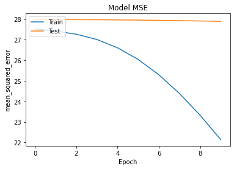

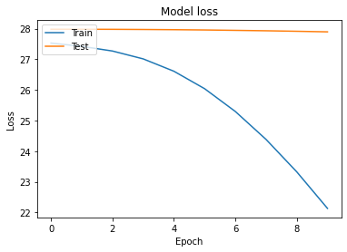

```
Model: 1,
Minimum RMSE at epoch: 10 = 5.281439083186521
```

```python
compile_fit_plot(model1, 1)
```

```
Model: "model_2"
__________________________________________________________________________________________________
Layer (type)                    Output Shape         Param #     Connected to
==================================================================================================
input_3 (InputLayer)            (None, 1)            0
__________________________________________________________________________________________________
input_4 (InputLayer)            (None, 1)            0
__________________________________________________________________________________________________
embedding_3 (Embedding)         (None, 1, 50)        314700      input_3[0][0]
__________________________________________________________________________________________________
embedding_5 (Embedding)         (None, 1, 50)        16800       input_4[0][0]
__________________________________________________________________________________________________
reshape_3 (Reshape)             (None, 50)           0           embedding_3[0][0]
__________________________________________________________________________________________________
reshape_5 (Reshape)             (None, 50)           0           embedding_5[0][0]
__________________________________________________________________________________________________
embedding_4 (Embedding)         (None, 1, 1)         6294        input_3[0][0]
__________________________________________________________________________________________________
embedding_6 (Embedding)         (None, 1, 1)         336         input_4[0][0]
__________________________________________________________________________________________________
dot_2 (Dot)                     (None, 1)            0           reshape_3[0][0]
                                                                 reshape_5[0][0]
__________________________________________________________________________________________________
reshape_4 (Reshape)             (None, 1)            0           embedding_4[0][0]
__________________________________________________________________________________________________
reshape_6 (Reshape)             (None, 1)            0           embedding_6[0][0]
__________________________________________________________________________________________________
add_1 (Add)                     (None, 1)            0           dot_2[0][0]
                                                                 reshape_4[0][0]
                                                                 reshape_6[0][0]
__________________________________________________________________________________________________
activation_1 (Activation)       (None, 1)            0           add_1[0][0]
__________________________________________________________________________________________________
lambda_1 (Lambda)               (None, 1)            0           activation_1[0][0]
==================================================================================================
Total params: 338,130
Trainable params: 338,130
Non-trainable params: 0
__________________________________________________________________________________________________
```

```
Train on 7500 samples, validate on 2501 samples
```

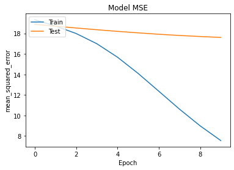

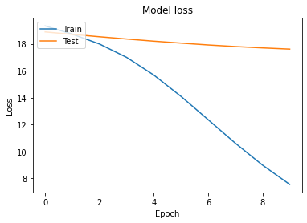

```
Model: 2,
Minimum RMSE at epoch: 10 = 4.196514621874424
```

```python
compile_fit_plot(model2, 2)
```

```
Model: "model_3"
__________________________________________________________________________________________________
Layer (type)                    Output Shape         Param #     Connected to
==================================================================================================
input_5 (InputLayer)            (None, 1)            0
__________________________________________________________________________________________________
input_6 (InputLayer)            (None, 1)            0
__________________________________________________________________________________________________
embedding_7 (Embedding)         (None, 1, 50)        314700      input_5[0][0]
__________________________________________________________________________________________________
embedding_8 (Embedding)         (None, 1, 50)        16800       input_6[0][0]
__________________________________________________________________________________________________
reshape_7 (Reshape)             (None, 50)           0           embedding_7[0][0]
__________________________________________________________________________________________________
reshape_8 (Reshape)             (None, 50)           0           embedding_8[0][0]
__________________________________________________________________________________________________
concatenate_1 (Concatenate)     (None, 100)          0           reshape_7[0][0]
                                                                 reshape_8[0][0]
__________________________________________________________________________________________________
dropout_1 (Dropout)             (None, 100)          0           concatenate_1[0][0]
__________________________________________________________________________________________________
dense_1 (Dense)                 (None, 10)           1010        dropout_1[0][0]
__________________________________________________________________________________________________
activation_2 (Activation)       (None, 10)           0           dense_1[0][0]
__________________________________________________________________________________________________
dropout_2 (Dropout)             (None, 10)           0           activation_2[0][0]
__________________________________________________________________________________________________
dense_2 (Dense)                 (None, 1)            11          dropout_2[0][0]
__________________________________________________________________________________________________
activation_3 (Activation)       (None, 1)            0           dense_2[0][0]
__________________________________________________________________________________________________
lambda_2 (Lambda)               (None, 1)            0           activation_3[0][0]
==================================================================================================
Total params: 332,521
Trainable params: 332,521
Non-trainable params: 0
__________________________________________________________________________________________________
```

```
Train on 7500 samples, validate on 2501 samples
```

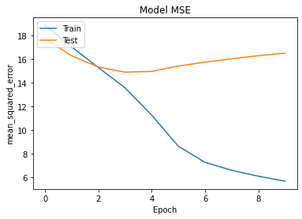

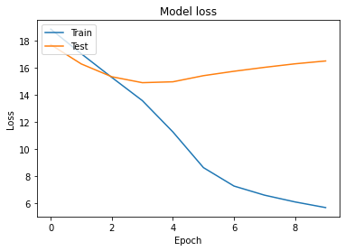

```
Model: 3,
Minimum RMSE at epoch: 4 = 3.858641118489675
```

```python
compile_fit_plot(model3, 3)
```

Our `model3` using Keras model gives better RMSE value compare to previous model using KNNBasic() and SVD()

```python
# intialise data of lists.
data = {'Model':['Keras', 'SVD', 'KNNBasic'], 'RMSE value':[3.85, 3.86, 4.11]}

# Create DataFrame
rmse_comparison = pd.DataFrame(data)

# Print the output.
print("Comparison Table \n", rmse_comparison)
```

```
Comparison Table
       Model  RMSE value
0     Keras        3.85
1       SVD        3.86
2  KNNBasic        4.11
```

**4.3 Use your trained model to recommend books for user with ID 6293. (0.5 points)**

We'll using `model3` for our model prediction, because it gives the best value of RMSE

```python
user_ratings_3, recommendations_3 = predict_recommend(model3,6293)
```

```python
user_ratings_3
```

|  | UserID | BookID_Encoded | Book-Rating | prediction |
| --- | --- | --- | --- | --- |
| 9998 | 6293 | 128 | 4 | 3.453737 |
| 9999 | 6293 | 145 | 5 | 4.495471 |
| 10000 | 6293 | 116 | 1 | 5.688742 |

```python
# recommendations_3
result = recommendations_3.sort_values(by=['prediction'], ascending = False).head(5)
result
```

|  | BookID_Encoded | prediction |
| --- | --- | --- |
| 1818 | 143 | 7.283206 |
| 4768 | 93 | 7.108502 |
| 3175 | 248 | 7.024966 |
| 4227 | 319 | 6.924546 |
| 4337 | 105 | 6.796365 |

```python
# get reverse mapper
mapper = book_to_idx
reverse_mapper = {v: k for k, v in mapper.items()}
# print recommendations
print('Book recommendations for user 6293:\n')

for i in result['BookID_Encoded']:
    print("- ", reverse_mapper[i])
```

```
Book recommendations for user 6293:

-  Harry Potter and the Order of the Phoenix (Book 5)
-  Die Kunst des Verschwindens.
-  Random Acts of Kindness
-  Undank ist der V�?¤ter Lohn.
-  Die Zwei Turme II
```

## How long did it take you to solve the homework?

- Please answer as precisely as you can. It does not affect your points or grade in any way. It is okay, if it took 0.5 hours or 24 hours. The collected information will be used to improve future homeworks.

**Answer:**

**(please change X in the next cell into your estimate)**

15 hours

## What is the level of difficulty for this homework?

you can put only number between $0:10$ ($0:$ easy, $10:$ difficult)

**Answer:** 7